# Perfil alélico HLA-B em pacientes admitidos por COVID-19 na Unidade de Tratamento Intensivo (UTI) do Hospital Municipal Padre Germano Lauck (Foz do Iguaçu/PR, Brasil) entre 2020 e 2021

2022-08-31

# Procedimentos

Esse material apresenta uma explicação detalhada dos procedimentos de análise realizados no projeto de Iniciação Científica “*Perfil alélico HLA-B em pacientes admitidos por COVID-19 na Unidade de Tratamento Intensivo (UTI) do Hospital Municipal Padre Germano Lauck (Foz do Iguaçu/PR, Brasil) entre 2020 e 2021*”, realizado com apoio do CNPq e da Universidade Federal da Integração Latino-Americana (UNILA). O projeto foi conduzido pelo bolsista Samuel Chagas de Assis, graduando em Biotecnologia, e orientado pela Profa. Dra. Maria Cláudia Gross com co-orientação da Profa. Dra. Maria Leandra Terencio e do Prof. Dr. Carlos Henrique Schneider. O grupo controle está fora do escopo dessa parte do projeto, o objetivo desse trabalho foi identificar padrões clínicos e genéticos na UTI entre 2020 e 2021. Futuramente, o grupo controle (enfermaria 2020) será incluído.

Mais informações podem ser acessadas em:

- [Relatório](https://github.com/chagas98/hlafozpublic/tree/main/Documents)
- [Resumo Expandido EICTI](https://github.com/chagas98/hlafozpublic/tree/main/Documents)
- [Código](https://github.com/chagas98/hlafozpublic)

Dados (Entrada e Resultados)

- [Dados de Entrada e Sequências](https://github.com/chagas98/hlafozpublic/tree/main/input)
- [Resultados adicionais](https://github.com/chagas98/hlafozpublic/tree/main/results)

Descrição das Figuras e Tabelas:

# Tabela 1

A tabela com as variáveis clínicas foi processada a partir do pacote R `gt_summary` utilizando os dados coletados em `data_final`. Sendos todas as comparações de grupos independentes, os p-valores foram calculados por teste rank sum de Wilcoxon (ou Mann-Whitney U) para variáveis contínuas não-paramétricas, teste de qui-quadrado de Pearson ou teste exato de Fisher bicaudal para variáveis categóricas, aplicadas em amostras menores (alguma amostragem <10) ou maiores, respectivamente. Váriaveis paramétricas e não-paramétricas foram representadas como médias (DP - Desvio Padrão) e mediana (IQR - intervalo interquartil), respectivamente. As amostragens de 2020 e 2021 foram analisadas separadamente (2020 vs. 2021) e sub-agrupadas em relação ao desfecho de cada paciente (Alta20 vs. Obito20 e Alta21 vs. Obito21).

|  | Desfechos Alta20, N = 141 | Desfechos Alta21, N = 261 | Desfechos Óbito20, N = 131 | Desfechos Óbito21, N = 211 | Desfechos 2020, N = 271 | Desfechos 2021, N = 471 | p-valores Alta20 vs. Obito202 | p-valores Alta21 vs. Obito212 | p-valores 2020 vs. 20212 |
| --- | --- | --- | --- | --- | --- | --- | --- | --- | --- |
| Idade (em anos) | 57.5 (52.8, 62.5) | 44.0 (42.0, 50.0) | 75.0 (65.0, 79.0) | 58.0 (54.0, 65.0) | 64.0 (55.5, 75.5) | 52.0 (43.0, 58.5) | 0.010 | <0.001 | <0.001 |
| Faixa-etária (em anos) |  |  |  |  |  |  | 0.029 | <0.001 | 0.002 |
| 20-29 | 0.0 (0.0%) | 0.0 (0.0%) | 1.0 (7.7%) | 0.0 (0.0%) | 1.0 (3.7%) | 0.0 (0.0%) |  |  |  |
| 30-39 | 1.0 (7.1%) | 6.0 (23.1%) | 0.0 (0.0%) | 1.0 (4.8%) | 1.0 (3.7%) | 7.0 (14.9%) |  |  |  |
| 40-49 | 2.0 (14.3%) | 13.0 (50.0%) | 0.0 (0.0%) | 2.0 (9.5%) | 2.0 (7.4%) | 15.0 (31.9%) |  |  |  |
| 50-59 | 7.0 (50.0%) | 5.0 (19.2%) | 1.0 (7.7%) | 11.0 (52.4%) | 8.0 (29.6%) | 16.0 (34.0%) |  |  |  |
| 60-69 | 2.0 (14.3%) | 2.0 (7.7%) | 4.0 (30.8%) | 5.0 (23.8%) | 6.0 (22.2%) | 7.0 (14.9%) |  |  |  |
| 70-79 | 2.0 (14.3%) | 0.0 (0.0%) | 6.0 (46.2%) | 2.0 (9.5%) | 8.0 (29.6%) | 2.0 (4.3%) |  |  |  |
| 80+ | 0.0 (0.0%) | 0.0 (0.0%) | 1.0 (7.7%) | 0.0 (0.0%) | 1.0 (3.7%) | 0.0 (0.0%) |  |  |  |
| Sex |  |  |  |  |  |  | 0.085 | 0.7 | 0.6 |
| Feminino | 4.0 (28.6%) | 14.0 (53.8%) | 8.0 (61.5%) | 10.0 (47.6%) | 12.0 (44.4%) | 24.0 (51.1%) |  |  |  |
| Masculino | 10.0 (71.4%) | 12.0 (46.2%) | 5.0 (38.5%) | 11.0 (52.4%) | 15.0 (55.6%) | 23.0 (48.9%) |  |  |  |
| Raça Autodeclarada |  |  |  |  |  |  | >0.9 | >0.9 | 0.8 |
| Asiática | 1.0 (7.1%) | 1.0 (3.8%) | 0.0 (0.0%) | 0.0 (0.0%) | 1.0 (3.7%) | 1.0 (2.1%) |  |  |  |
| Branca | 7.0 (50.0%) | 10.0 (38.5%) | 7.0 (53.8%) | 10.0 (47.6%) | 14.0 (51.9%) | 20.0 (42.6%) |  |  |  |
| Parda | 6.0 (42.9%) | 14.0 (53.8%) | 6.0 (46.2%) | 11.0 (52.4%) | 12.0 (44.4%) | 25.0 (53.2%) |  |  |  |
| Preta | 0.0 (0.0%) | 1.0 (3.8%) | 0.0 (0.0%) | 0.0 (0.0%) | 0.0 (0.0%) | 1.0 (2.1%) |  |  |  |
| Número de Comorbidades |  |  |  |  |  |  | 0.3 | 0.4 | 0.8 |
| ≥ 3 Comorbidades | 1.0 (7.1%) | 0.0 (0.0%) | 0.0 (0.0%) | 2.0 (9.5%) | 1.0 (3.7%) | 2.0 (4.3%) |  |  |  |
| 1 Comorbidade | 6.0 (42.9%) | 10.0 (38.5%) | 6.0 (46.2%) | 6.0 (28.6%) | 12.0 (44.4%) | 16.0 (34.0%) |  |  |  |
| 2 Comorbidades | 3.0 (21.4%) | 8.0 (30.8%) | 6.0 (46.2%) | 8.0 (38.1%) | 9.0 (33.3%) | 16.0 (34.0%) |  |  |  |
| Sem Comorbidades | 4.0 (28.6%) | 8.0 (30.8%) | 1.0 (7.7%) | 5.0 (23.8%) | 5.0 (18.5%) | 13.0 (27.7%) |  |  |  |
| Tabagismo |  |  |  |  |  |  | 0.058 | 0.5 | 0.2 |
| Ex | 6.0 (42.9%) | 2.0 (7.7%) | 1.0 (7.7%) | 4.0 (19.0%) | 7.0 (25.9%) | 6.0 (12.8%) |  |  |  |
| Ignorado | 1.0 (7.1%) | 3.0 (11.5%) | 5.0 (38.5%) | 4.0 (19.0%) | 6.0 (22.2%) | 7.0 (14.9%) |  |  |  |
| Não | 6.0 (42.9%) | 19.0 (73.1%) | 4.0 (30.8%) | 11.0 (52.4%) | 10.0 (37.0%) | 30.0 (63.8%) |  |  |  |
| Sim | 1.0 (7.1%) | 2.0 (7.7%) | 3.0 (23.1%) | 2.0 (9.5%) | 4.0 (14.8%) | 4.0 (8.5%) |  |  |  |
| Alcoolismo |  |  |  |  |  |  | 0.2 | 0.8 | 0.3 |
| Ex | 1.0 (7.1%) | 0.0 (0.0%) | 0.0 (0.0%) | 0.0 (0.0%) | 1.0 (3.7%) | 0.0 (0.0%) |  |  |  |
| Ignorado | 3.0 (21.4%) | 8.0 (30.8%) | 8.0 (61.5%) | 9.0 (42.9%) | 11.0 (40.7%) | 17.0 (36.2%) |  |  |  |
| Não | 8.0 (57.1%) | 17.0 (65.4%) | 4.0 (30.8%) | 11.0 (52.4%) | 12.0 (44.4%) | 28.0 (59.6%) |  |  |  |
| Sim | 2.0 (14.3%) | 1.0 (3.8%) | 1.0 (7.7%) | 1.0 (4.8%) | 3.0 (11.1%) | 2.0 (4.3%) |  |  |  |
| Coinfec. Bacteriana |  |  |  |  |  |  | 0.3 | 0.3 | 0.6 |
| Não | 6.0 (42.9%) | 10.0 (38.5%) | 8.0 (61.5%) | 11.0 (52.4%) | 14.0 (51.9%) | 21.0 (44.7%) |  |  |  |
| Sim | 8.0 (57.1%) | 16.0 (61.5%) | 5.0 (38.5%) | 10.0 (47.6%) | 13.0 (48.1%) | 26.0 (55.3%) |  |  |  |
| Dias de Internação | 31.5 (26.2, 41.5) | 29.5 (20.0, 40.0) | 22.0 (19.0, 32.0) | 28.0 (19.0, 36.0) | 30.0 (20.0, 39.5) | 29.0 (19.5, 38.0) | 0.3 | 0.6 | >0.9 |
| Dias de UTI | 25.5 (17.8, 30.8) | 24.0 (11.2, 35.0) | 20.0 (13.0, 30.0) | 24.0 (16.0, 30.0) | 25.0 (14.5, 30.5) | 24.0 (13.5, 35.0) | 0.6 | 0.8 | 0.8 |
| Dias de Suporte Ventilatório | 17.5 (11.2, 24.5) | 20.5 (9.2, 29.2) | 22.0 (13.0, 30.0) | 25.0 (18.0, 36.0) | 20.0 (11.5, 30.0) | 24.0 (13.0, 32.5) | 0.3 | 0.057 | 0.6 |
| Período Primeiros Sintomas | 9.2 (3.8) | 9.7 (4.8) | 6.2 (5.0) | 9.5 (3.4) | 7.7 (4.6) | 9.6 (4.2) | 0.075 | 0.7 | 0.058 |

1Median (IQR); n (%); Mean (SD)  
2Wilcoxon rank sum test; Fisher's exact test; Pearson's Chi-squared test

# Figura 1 e Tabela 2

As Figuras 1 e Tabela 2 apresentam a frequência dos alelos identificados a partir da genotipagem (descritos no relatório) dos grupos amostrais de 2020 e 2021, além da análise estatística.

### Figura 1

A Figura 1A foi obtida através do pacote R `ggplot2` e apresenta a frequência dos alelos em ambos anos amostrais. Os alelos com menor frequência de ocorrência (<5% ou <5 ocorrências) de cada ano foram agrupados para reduzir a interferência de possíveis erros de sequenciamento e os níveis de variações de *outliers* presentes nas amostragens. A linha tracejada marca o limiar n = 5 e as anotações destacadas do eixo x representam os alelos não agrupados em `binned`, grupo de alelos com frequência <%5. A Figura 1B representa as frequências obtidas a partir de cada ano e sub-agrupadas nos desfechos.

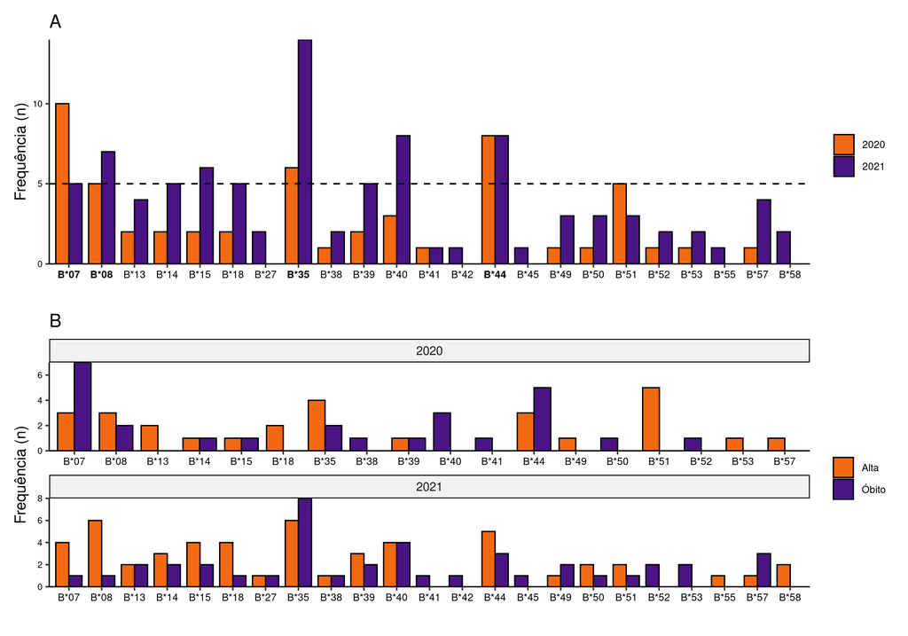

Figura 1 - Frequência dos alelos identificados. (A) agrupados em ano de coleta e (B) desfecho por ano de coleta. A linha tracejada em (A), n = 5, identifica os alelos com menor e maior frequência; as anotações destacadas no eixo x representam os alelos de maior frequência, não agrupados em “binned”.

[output not shown]

# Figura 2

As variáveis e indicadores clínicos foram correlacionadas utilizando o pacote R `correlation`. As varíáveis independentes foram selecionadas considerando baixo percentual de dados ignorados/faltantes e em nível de significância comparado aos relatos da literatura. Além disso, variáveis dependentes, desfechou ou tempo de hospitalização, foram adicionadas buscando compreender a interação entre as variáveis para definição de potenciais preditores e confudidores que podem ser adicionados nos modelos de regressão. A função `correlation()` foi ajustada para função automática (“auto”), buscando selecionar os métodos mais relevantes para cada tipo de variável. Correlação policrônica foi conduzida quando valores ordinais estavam envolvidos (por exemplo, tabagismo, 1 - Não, 2 - Ex, 3 - Sim ), tetracrônica quando as variáveis possuem fatores binários, ponto-biserial para comparações entre binárias com valores contínuos e Pearson para testes contendo variáveis contínuas, etc. A função foi ajustada para executar correlações parciais condicionada a outras variáveis. Além disso, os p-valores foram corrigidos para múltiplas comparações utilizando a abordagem de Bonferroni.

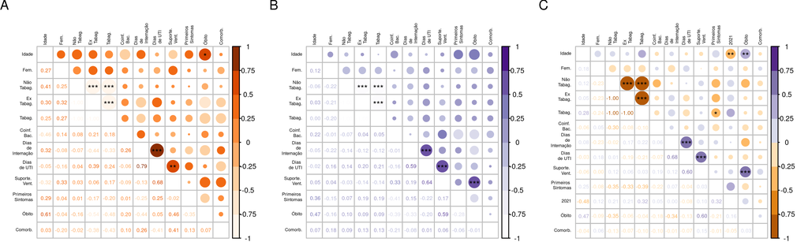

Figura 2 - Correlação entre variáveis clínicas em (A) 2020, (B) 2021 e (c) ambos os anos. p < 0.05 (*), p < 0.02 (**), p < 0.01 (***)

## Tabela 3

O modelo para avaliar a associação entre os grupos alélicos HLA-B foram conduzido por um modelo de associação aditivo (h/h vs h/- vs -/-). O desfecho (alta - 0, óbito - 1) ou ano de coleta ( 2020 - 0, 2021 - 1) foram utilizados como variáveis dependentes para avaliar a influcência dos alelos e alelos ajustados com a idade. O modelo de regressão logística foi implementado utilizando o pacote R `HIBAG` e as funções `hlaAllele()` e `hlaAssociTest` foram utilizados para calcular as estimativas de razão de chances (OR), intervalo de confiança (CI) e p-valores. Foram testados os sub-grupos em cada ano baseado no desfecho, os quais não apresentaram resultados significativos, mesmo ajustados para idade. Enquanto isso, avaliou-se a ocorrência de cada um dos grupos alélicos entre os dois ano de coleta, os quais apresentaram as seguintes significâncias:

| Alelos | OR | 2.5%CI | 97.5%CI | p | p.adj |
| --- | --- | --- | --- | --- | --- |
| B*07 | 0.25 | 0.07 | 0.93 | 0.04 | 0.19 |
| B*08 | 0.68 | 0.20 | 2.37 | 0.54 | 1.00 |
| B*35 | 1.36 | 0.41 | 4.56 | 0.62 | 1.00 |
| B*44 | 0.69 | 0.20 | 2.41 | 0.56 | 1.00 |
| binned | 2.22 | 0.95 | 5.16 | 0.06 | 0.32 |

## Figura 3

$$\hat{ICUdays_y} = e^{Intercept+
b_{1}I(X_{B_{08}})...+b_{j}I(X_{B_{binned}}) +
b_{j+1}(X_c)}$$

A análise foi conduzida com alelos com frequência superior a 0.05% (ou >5 ocorrências em cada coleta), sendo $j$ o número de alelos selecionados, e o restante agrupados em `binned`, ajustando para variáveis clínicas $X_c$. Como não houve um grupo controle/tratamento, a seguinte análise foi conduzida com caráter descritivo buscando a razão de efeito entre os alelos coletados de cada ano separadamente. Através do pacote R `MASS`, o modelo foi processado pela função `glm.nb()` e as médias marginais modeladas de cada alelo foram obtidas através do pacote R `emmeans` com a função `emmeans()`, onde o modelo em função de ligação logaritimica possuem efeito aditivo, ou seja, os expoentes dos coeficientes são as médias de cada alelo para o período na UTI. Devido a falta de um grupo controle, o alelo com a menor média de incidência foi utilizado como base para o cálculo da regressão (`intercept`), ou seja, o grupo alélico `B*07`. Os modelos foram separados em 2020 e 2021 ($ICUdays_{2020}$ e $ICUdays_{2021}$), assim como testado com covariáveis de desfecho e idade, identificados na análise de correlação e com relevância clínica, respectivamente. No entanto, em uma ánalise *post hoc* das médias modeladas, a razão de efeito foi conduzida entre os grupos alélicos e o efeito de cada alelo em relação a média geral dos grupos analisados. O modelo não apresentou alteração significativa quando ajustado para `idade` (dados não apresentados).

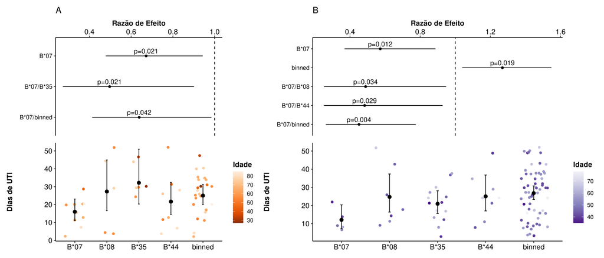

Figura 3 - Razão de efeito a partir do modelo de regressão binomial negativa ajustado para idade para (A) 2020 e (B) 2021

## Figura 4

$$\hat{ICUdays_y} = e^{Intercept +
b_{interaction}(HLAB_{08}*Outcome) ... +
b_{interaction}(HLAB_{binned}*Outcome)}$$

A Figura 4 utiliza do mesmo procedimento utilizado na Figura 3, mas buscando avaliar a interação entre os grupos alélicos e desfecho no tempo de permanência na UTI.

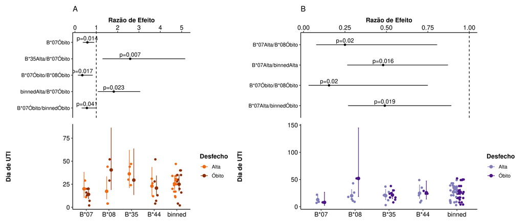

## Materiais Suplementares

### Figura S1

Os *outliers* foram retirados utilizando `dplyr::filter()`, excluindo pacientes com dias de internação superior a 65 dias.

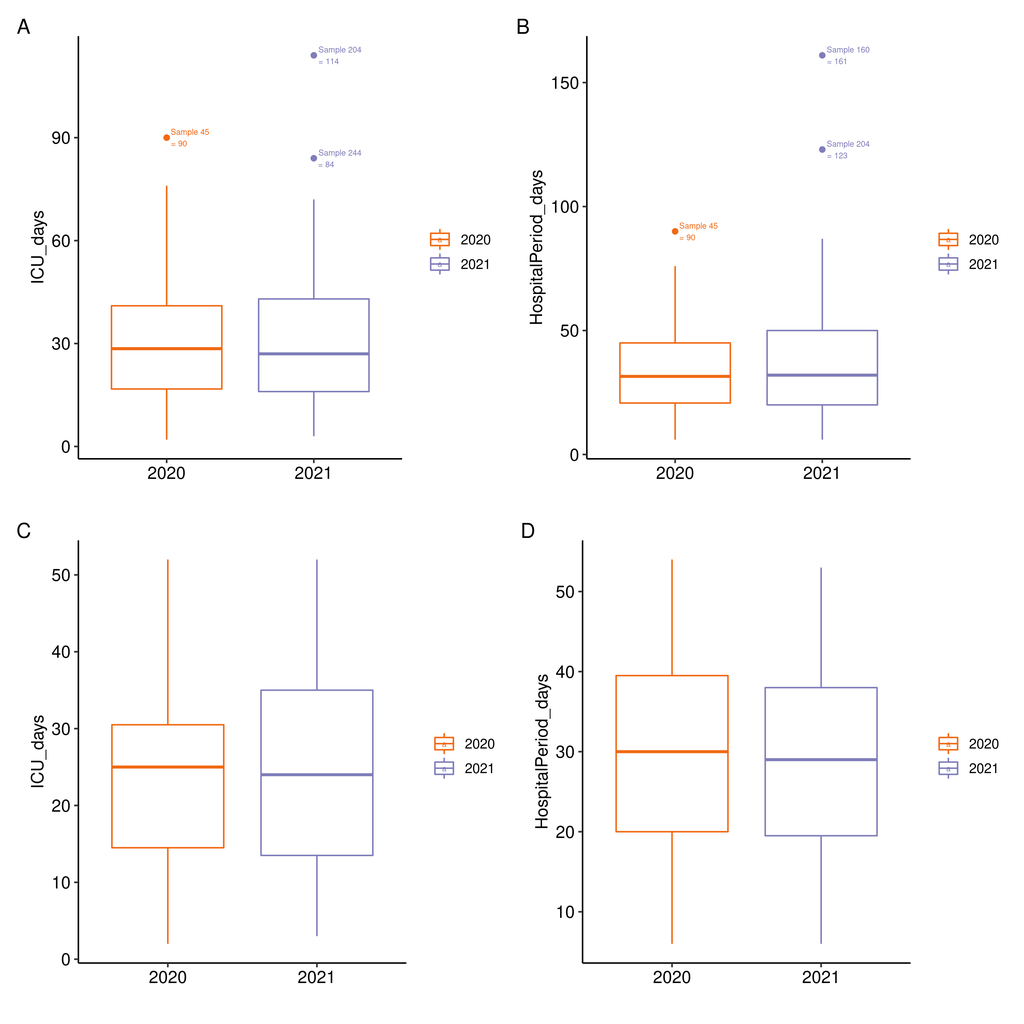

### Figura S2

Os pacientes foram selecionados ao final de cada onda epidemiológica como descrito em (Bastos et al., 2021).

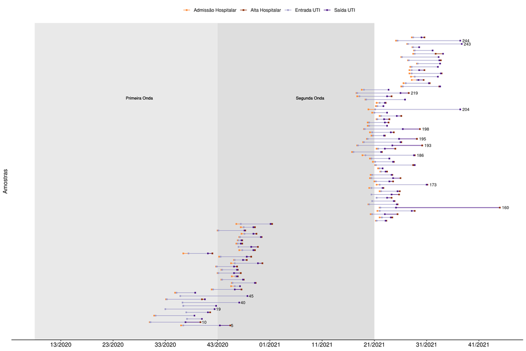

Figura S2 - Período de coleta das amostras. Amostras identificadas com seus respectivos números foram filtradas (>65 dias). Primeria onda: 8/2020 à 43/2020 semana; Segunda onda: 43/2020 à 21/2021.

### Figura S3

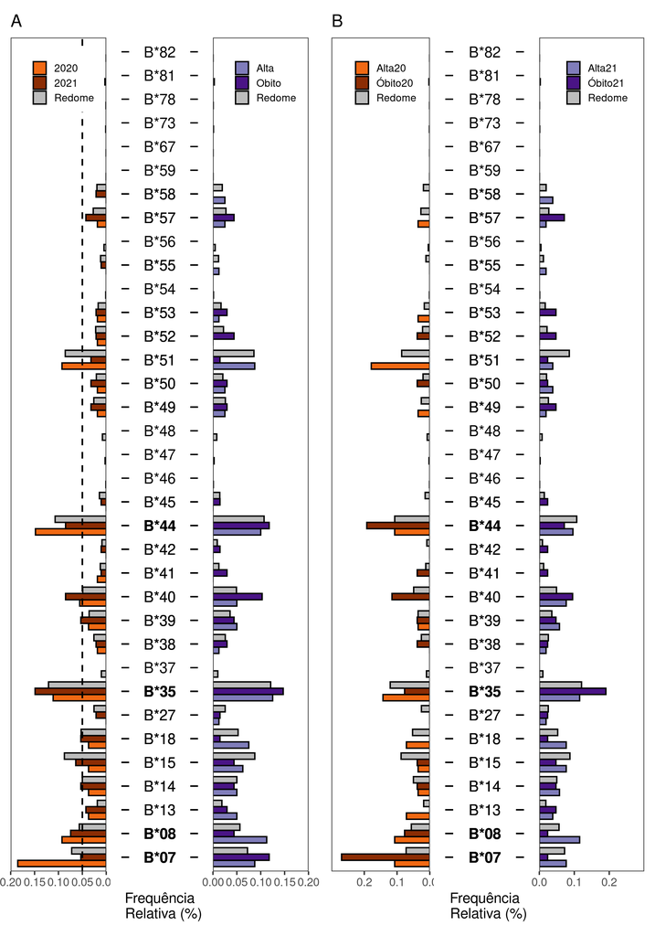

### Models Check

#### ICU_days ~ allele + Age (2020)

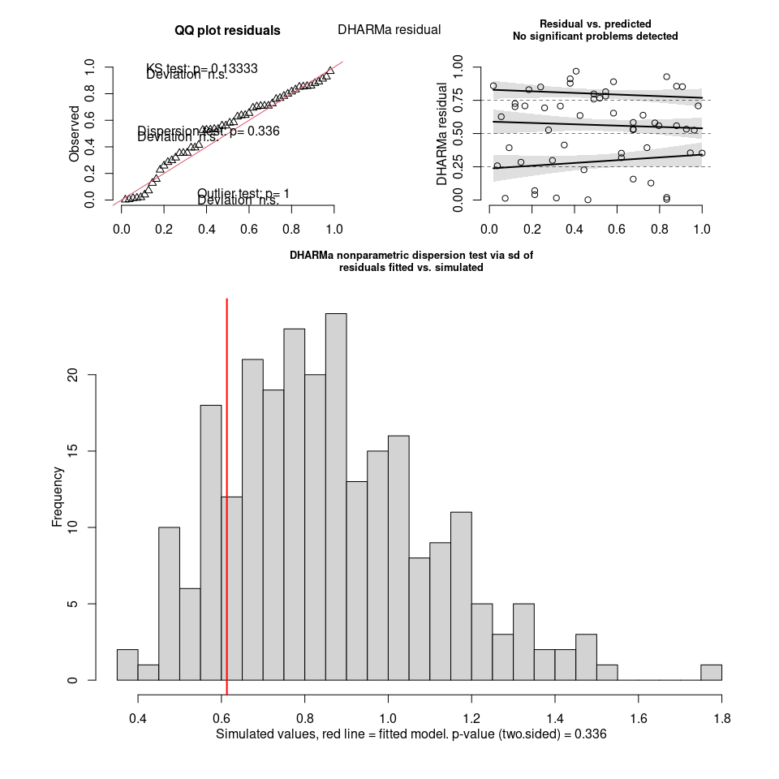

ICU_days ~ allele + Age.

#### ICU_days ~ allele + Age (2021)

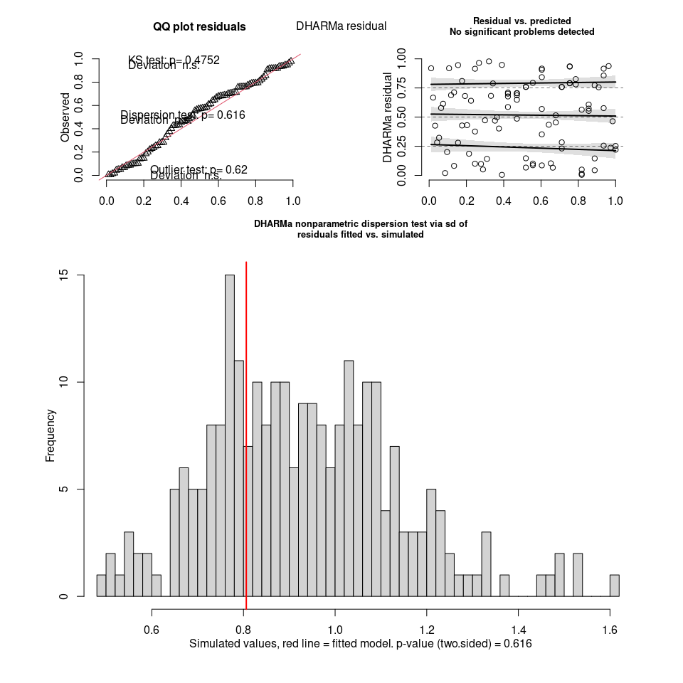

ICU_days ~ allele + Age.

#### ICU_days ~ allele*Outcome (2020)

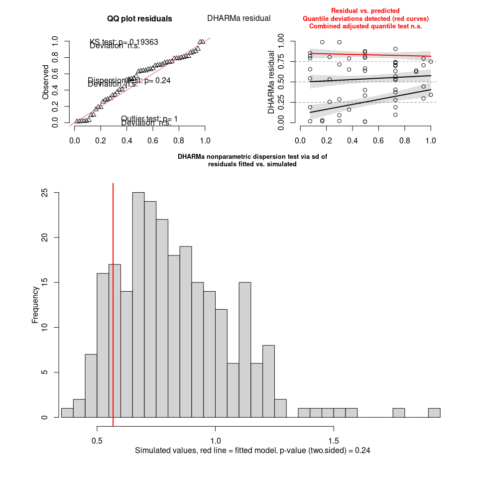

ICU_days ~ allele*Outcome

#### ICU_days ~ allele*Outcome (2021)

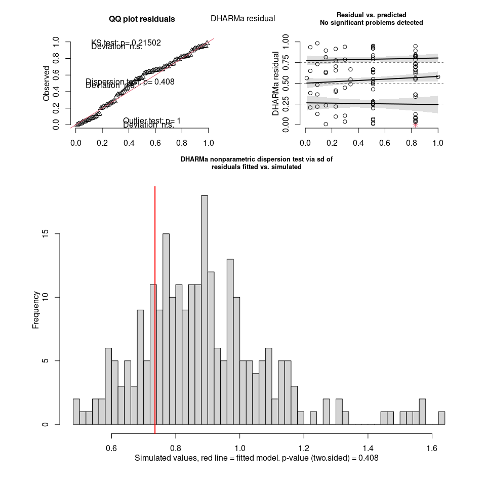

ICU_days ~ allele*Outcome

# REFERÊNCIAS

BASTOS, L. S. et al. COVID-19 hospital admissions: Brazil’s first and second waves compared. **The Lancet Respiratory Medicine**, v. 9, n. 8, p. e82–e83, ago. 2021. Disponível em: <https://www.thelancet.com/journals/lanres/article/PIIS2213-2600%2821%2900287-3/fulltext>. Acesso em: 16 set. 2022.https://doi.org/10.1016/S2213-2600(21)00287-3.

GONZALEZ-GALARZA, F. F. et al. Allele frequency net database (AFND) 2020 update: gold-standard data classification, open access genotype data and new query tools. **Nucleic Acids Research**, v. 48, n. D1, p. D783–D788, jan. 2020. Disponível em: <https://doi.org/10.1093/nar/gkz1029>. Acesso em: 16 jul. 2022.https://doi.org/10.1093/nar/gkz1029.